# 461 Final Project

2024-12-10

# Introduction

The following project aims to identify an appropriate model for the Walmart daily adjusted closing stock price from January 1, 2020 to December 6, 2023.

# Exploratory Data Analysis

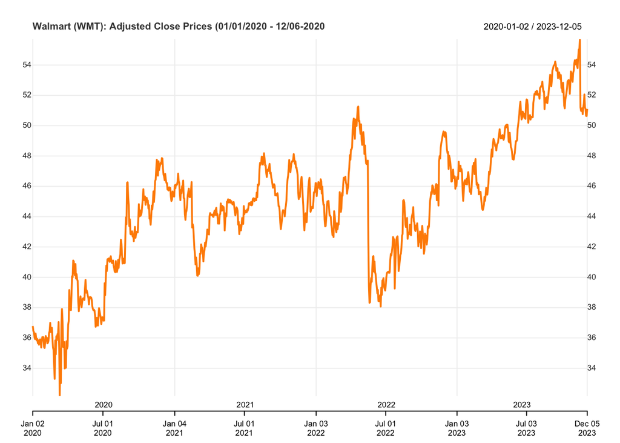

```r
#visualize original series
chart_Series(adj.close, name = "Walmart (WMT): Adjusted Close Prices (01/01/2020 - 12/06-2020")
```

### Original Time Series Observations / Comments

Based on a time series graph of the Walmart daily adjusted closing stock price from January 1, 2020 to December 6, 2023, the following initial observations may be made:

1. Non-stationary:
   1. Non-constant mean. As time progresses, the average value of the series increases.
   2. Non-constant variance:
      1. Volatility Clustering- where large changes in the series are followed by large changes of either sign, and small changes tend to be followed by small changes
         1. For example:
            1. Between January 2020 to July 2020 we may notice a series of rapid decline, followed by an increase
2. From January 2020 - January 2021, the series, overall, demonstrates an upward trend, however, come January 2021 this narrative changes. Throughout 2021 and the first half of 2022 (January 2022 - July 2022), the series remains relatively stagnant; showing neither an overall increase, nor decrease. Just before July 2022, the series reaches a peak of 52, before sharply declining to about 38. This is the most dramatic, short time frame fluctuation present in the series. Since this moment, the series, since July 2022 has shown a strong overall increasing trend. Likely this is the series attempt to stabilize post pandemic. In the long term, this looks to be promising.

### Stationary Tests On Original Data

To confirm that the original data series is non-stationary, I conducted an ADF Test and a KPSS Test. At a standard significance level of 0.05:

- For a stationary time series, the ADF Test will compute a p-value **less than** 0.05, rejecting the null hypothesis of non-stationarity.
- Conversely, a KPSS Test for a stationary time series will compute a p-value **greater than** 0.05, failing to reject the null hypothesis of stationarity.

In both tests, we have evidence of a non-stationary series. This confirms the initial observations that the series appears non-stationary. The ADF Test computes a p-value **greater than** 0.05, and the KPSS Test computes a p-value **less than** 0.05. These results support the observations made earlier, providing evidence that the original time series is non-stationary. The results of these tests are shown in the table below.

| Stationary Test Results Test | Stationary Test Results P.Value |
| --- | --- |
| ADF Test | 0.0785146 |
| KPSS Test | 0.0100000 |

### Transforming Into Stationary Series

Before modeling the series, it is essential to apply the necessary transformations to achieve stationarity.

Transformations:

1. First apply log transformation
   1. We first apply log transformation to convert the multiplicative series into an additive series
   2. Addresses non-constant variance
2. Difference of the log transformed data
   1. Address non-constant mean

The time series titled **“WMT: Log Returns, (d=1)”** represents the data after applying a log transformation and differencing the series once. This transformation effectively adjusted for the non-constant mean observed in the original series, as evidenced by the fact that the series is now relatively stabilized around zero. Overall, the series demonstrates relatively constant variance. However, there are still clear volatility or variance spikes that persist within the time frames in the original series that exhibited significant volatility.

These variance spikes are particularly notable during the following periods:

- **January 2020 to about July 2020**: This period exhibits high volatility, with larger spikes in the series.
- **Just prior to July 2022**: Another period of increased volatility is evident.

Despite the volatility spikes that are still evident in the series, the results of both, an ADF and a KPSS Test reveal that the transformed series is weakly stationary. The results of the ADF and KPSS Tests on the transformed series are shown in the table below, “**Stationary Test Results Differenced Log Returns (d=1)“.**

As shown in the ACF and PACF plots, the transformed series, although stationary, does not appear like white noise, weak or strong. This observation is further confirmed by the Box-Ljung test. The Box-Ljung test computed a p-value of 0.02366. For a Box-Ljung test, we reject the hypothesis that the series is like weak white noise for p-values < 0.05.

By running the auto.arima function, we are enabled to identify the model that fits this series.

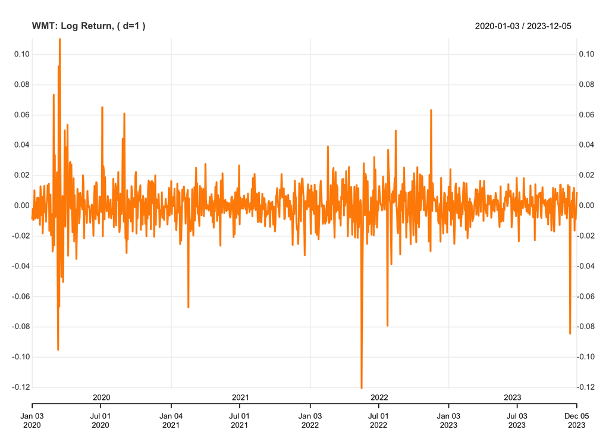

| Stationary Test Results Differenced Log Returns (d=1) Test | Stationary Test Results Differenced Log Returns (d=1) P.Value |
| --- | --- |
| ADF Test | 0.01 |
| KPSS Test | 0.10 |

```r
Box.test(diff.log.return, type = "Ljung") # Box-Ljung test: p-value > 0.05 => conclusion: weak white noise ||| p-value = 0.02366
```

```
##
##  Box-Ljung test
##
## data:  diff.log.return
## X-squared = 5.1191, df = 1, p-value = 0.02366
```

```r
Box.test(diff.log.return, type = "Ljung") # Box-Ljung test: p-value > 0.05 => conclusion: weak white noise ||| p-value = 0.02366
```

```
##
##  Box-Ljung test
##
## data:  diff.log.return
## X-squared = 5.1191, df = 1, p-value = 0.02366
```

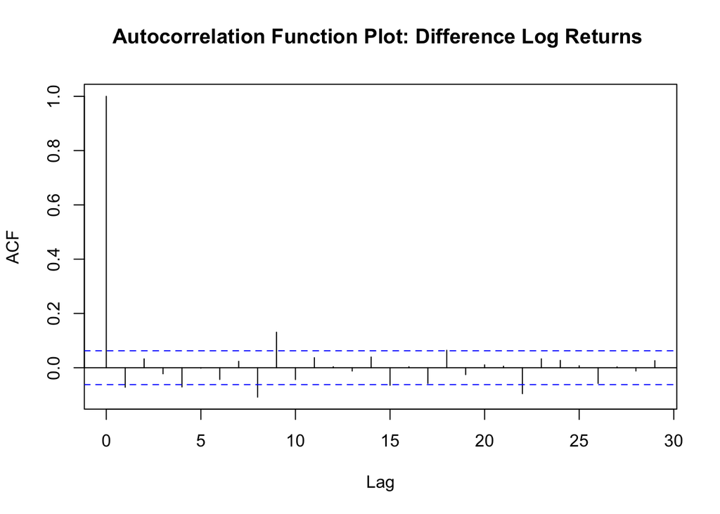

```r
acf(diff.log.return, main = "Autocorrelation Function Plot: Difference Log Returns ")
```

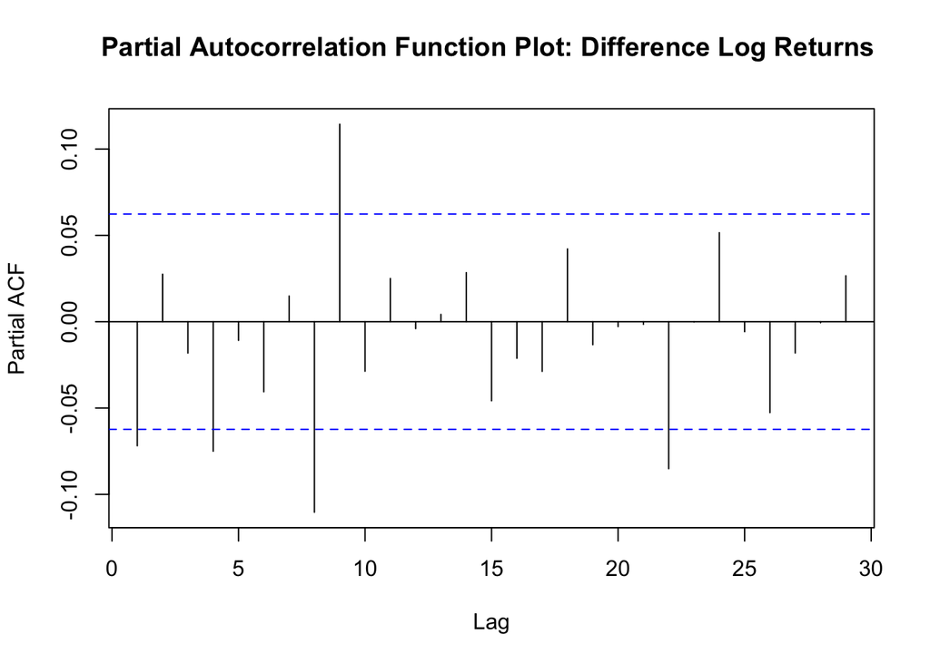

```r
pacf(diff.log.return, main = "Partial Autocorrelation Function Plot: Difference Log Returns ")
```

```r
auto.arima(diff.log.return)
```

```
## Series: diff.log.return
## ARIMA(0,0,1) with zero mean
##
## Coefficients:
##           ma1
##       -0.0676
## s.e.   0.0309
##
## sigma^2 = 0.0002234:  log likelihood = 2751.35
## AIC=-5498.71   AICc=-5498.69   BIC=-5488.91
```

```r
auto.arima(diff.log.return)$coef
```

```
##         ma1
## -0.06757478
```

The results of auto.arima suggest an MA(1) model for this series.

Now that stationarity has been achieved, we can begin identifying the appropriate order of the ARIMA model.

An ARIMA(p,d,q) model is a generalized ARMA(p,q) model for non-stationary data. Once an ARIMA(p,d,q) process is differenced ‘d’ times to achieve stationarity, the model becomes an ARMA(p,q) process.

Since we have established above that differencing the series once (d=1) achieves stationarity, the current objective is to determine the appropriate order of the stationary ARMA(p,q) process that best fits the transformed series.

**We begin this process by evaluating the autocorrelation function (acf) plot, and the partial autocorrelation function (pacf) plot.**

- ACF Plot:
  - For an Autoregressive Process of order p, AR(p), the auto-correlations will tail off towards zero as lag k increases.
  - For a Moving Average Process of order q, MA(q), the auto-correlation function is known to cut-off after order q. That is, for lags k>q, the autocorrelation function will equal 0.
- PACF Plot:
  - For an Autoregressive Process of order p, AR(p), the partiala auto-correlation cuts off after lag p. That is, for lags k > p, the partial auto-correlation function will equal 0.
  - For a Moving Average Process of order q, MA(q), the partial auto-correlation function will tail off towards zero as lag k increases.

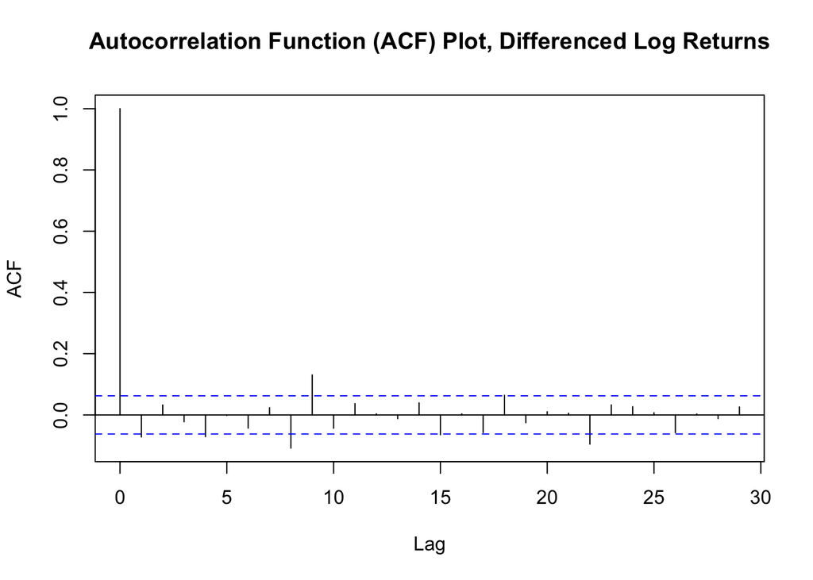

```r
######ORDER OF DATA######
acf(diff.log.return, main = "Autocorrelation Function (ACF) Plot, Differenced Log Returns")
```

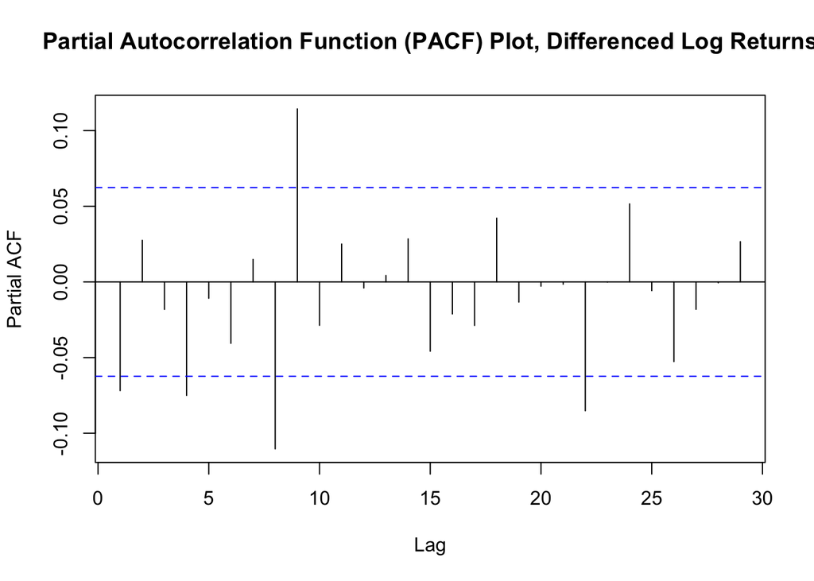

```r
pacf(diff.log.return, main = "Partial Autocorrelation Function (PACF) Plot, Differenced Log Returns")
```

```r
#eacf(diff.log.return)
auto.arima(diff.log.return) #ARIMA(0,0,1)
```

```
## Series: diff.log.return
## ARIMA(0,0,1) with zero mean
##
## Coefficients:
##           ma1
##       -0.0676
## s.e.   0.0309
##
## sigma^2 = 0.0002234:  log likelihood = 2751.35
## AIC=-5498.71   AICc=-5498.69   BIC=-5488.91
```

What do these results mean? The noisy, inconsistent ACF plot suggests that:

Heteroskedasticity is likely present in the series, distorting the autocorrelation structure. An ARMA process alone may not fully capture the dynamics, as the variance is changing over time. while ARMA(0,1) might model the mean process, additional modeling is needed to capture the variance structure.

```r
# acf(diff.log.return) # kind of white noise
# Box.test(diff.log.return, type = "Ljung") # Box-Ljung test: p-value > 0.05 => conclusion: kind of white noise ||| p-value = 0.02366
# adf.test(diff.log.return) # ADF test: stationary |||p-value = 0.01
# kpss.test(diff.log.return) # KPSS test: stationary ||| p-value = 0.1
#
# # Picking (p, q) together with d in ARIMA(p, d, q) is tricky in practice and requires a lot of trials and errors
# # but we can use auto.arima() from package "forecast" to determine orders as well as coefficients easily
# model = arima(diff.log.return, order = c(0, 0, 1), method = "ML")
# model # p = 2, d = 0, q = 2
#
# # However, checking residuals is still necessary
# plot(model) # unit root test, omega = 1/x strictly inside unit circle, not x
# res = resid(model)
# plot(res) # NOT equal var, i.e., heteroscedasticity
# acf(res) # white noise
# Box.test(res, type = "Ljung") # white noise
# qqnorm(res); qqline(res) #
```

code is below

```r
# model = garchFit(formula = ~ arma(0,1) + garch(1, 1), data = diff.log.return, trace = FALSE)
# model # mu: drift, close to zero, the true value
# model.sum = summary(model) # Standardised Residuals Tests: most of p-values > 0.05
# model.sum$ics["AIC"] # AIC. #-5.772181
# model.sum$ics["BIC"] # BIC #-5.747405
# res = residuals(model, standardize = T)
# acf(res)
# acf(res^2)
# acf(abs(res)) # all look good => strong white noise
# qqnorm(res); qqline(res) # normality test: not normal => maybe a different cond.dist is better
# ks.test(res, "pnorm") # normality test by Kolmogorov-Smirnov (KS) test: p-value < 0.05 => not normal |||| p-value = 0.0001336 < 0.05 => not normal
#
#
# model2 = garchFit(formula = ~ arma(0,0) + garch(1, 1), data = diff.log.return, trace = FALSE)
# model2 # mu: drift, close to zero, the true value
# model2.sum = summary(model2) # Standardised Residuals Tests: most of p-values > 0.05
# model2.sum$ics["AIC"] # AIC. -5.772055
# model2.sum$ics["BIC"] # BIC #-5.752235
# res2 = residuals(model2, standardize = T)
# acf(res2)
# acf(res2^2)
# acf(abs(res2)) # all look good => strong white noise
# qqnorm(res2); qqline(res2) # normality test: not normal => maybe a different cond.dist is better
# ks.test(res2, "pnorm") # normality test by Kolmogorov-Smirnov (KS) test: p-value < 0.05 => not normal ||| p-value = 5.106e-05 < 0.05 => not normal
#
#
#
# model3 = garchFit(formula = ~  garch(1, 0), data = diff.log.return, trace = FALSE)
# model3 # mu: drift, close to zero, the true value
# model3.sum = summary(model3) # Standardised Residuals Tests: most of p-values > 0.05
# model3.sum$ics["AIC"] # AIC. #-5.720861
# model3.sum$ics["BIC"] # BIC #-5.705996
# res3 = residuals(model3, standardize = T)
# acf(res3)
# acf(res3^2)
# acf(abs(res3)) # all look good => strong white noise
# qqnorm(res3); qqline(res3) # normality test: not normal => maybe a different cond.dist is better
# ks.test(res3, "pnorm") # normality test by Kolmogorov-Smirnov (KS) test: p-value < 0.05 => not normal ||| p-value = 1.823e-05 < 0.05 => not normal
#
# model4 = garchFit(formula = ~  garch(2, 0), data = diff.log.return, trace = FALSE)
# model4 # mu: drift, close to zero, the true value
# model4.sum = summary(model4) # Standardised Residuals Tests: most of p-values > 0.05
# model4.sum$ics["AIC"] # AIC. #-5.726807
# model4.sum$ics["BIC"] # BIC #-5.706986
# res3 = residuals(model3, standardize = T)
# acf(res3)
# acf(res3^2)
# acf(abs(res3)) # all look good => strong white noise
# qqnorm(res3); qqline(res3) # normality test: not normal => maybe a different cond.dist is better
# ks.test(res3, "pnorm") # normality test by Kolmogorov-Smirnov (KS) test: p-value < 0.05 => not normal ||| p-value = 1.823e-05 < 0.05 => not normal
#
```

```r
# acf(diff.log.return) # not quite weak white noise
# Box.test(diff.log.return, type = "Ljung") # Box-Ljung test: p-value > 0.05 => conclusion: weak white noise, at least uncorrelated ||| p-value = 0.02366
# adf.test(diff.log.return) # p-value < 0.05 => stationary ||| p-value = 0.01
# kpss.test(diff.log.return) # p-value > 0.05 => stationary ||| p-value = 0.1
#
# log.ret.abs = abs(diff.log.return)
# acf(log.ret.abs) # not like white noise
# Box.test(log.ret.abs, type = "Ljung") # Box-Ljung test: p-value < 0.05 => conclusion: not white noise, still dependent ||| p-value < 2.2e-16
#
# log.ret.sqr = diff.log.return^2
# acf(log.ret.sqr) # not like white noise
# Box.test(log.ret.sqr, type = "Ljung") # Box-Ljung test: p-value < 0.05 => conclusion: not white noise, still dependent ||| p-value < 2.2e-16
```

scratch

```r
# #Use log to convert multiplicative data (like stock price) to additive data (summation)
# log.return = log(adj.close)
#
#
# # differenced log returns and plot series
# diff.log.ret = diff(log(adj.close))[-1];
# chart_Series(diff.log.ret,name ="WMT: (Diff) Log Returns" )
#
# #check to see if difference log return series is stationary
# adf.test(diff.log.ret) # p-value < 0.05 => stationary ||| p-value = 0.01 < 0.05 => stationary
# kpss.test(diff.log.ret) # p-value > 0.05 => stationary ||| p-value = 0.1 > 0.05 => stationary
#
# #white noise?
# Box.test(diff.log.ret, type = "Ljung") #p-value > 0.05 => conclusion: weak white noise, at least uncorrelated ||| p-value = 0.02366 < 0.05 => conclusion: NOT like weak white noise
```

ARIMA Workflow (scratch)

```r
# #data
# diff.log.ret = diff(log(adj.close))[-1]
#
# #acf plot
# acf(diff.log.ret)
#
# #pacf plot
# pacf(diff.log.ret)
#
#
#
# acf(diff.log.ret) # weak white noise, at least uncorrelated
# Box.test((diff.log.ret), type = "Ljung") # Box-Ljung test: p-value > 0.05 => conclusion: weak white noise, at least uncorrelated
# adf.test(log.ret) # p-value < 0.05 => stationary
# kpss.test(log.ret) # p-value > 0.05 => stationary
#
# log.ret.abs = abs(log.ret)
# acf(log.ret.abs) # not like white noise
# Box.test(log.ret.abs, type = "Ljung") # Box-Ljung test: p-value < 0.05 => conclusion: not white noise, still dependent
#
# log.ret.sqr = log.ret^2
# acf(log.ret.sqr) # not like white noise
# Box.test(log.ret.sqr, type = "Ljung") # Box-Ljung test: p-value < 0.05 => conclusion: not white noise, still dependent
```